# 2 About SD Desktop

## 2.1 Overview

Where to find things:

[figure not shown]

- Applications:
  - Start applications
- External Drive:
  - For backup of project data and documents by the project manager
- Data Gateway:
  - Mount SD Connect drive with sensitive data
- Shared-directory:
  - This is where all project data and software should be kept

Ctrl+C and Ctrl+V do not always work in this version of Linux, for example it won’t work in the terminal. You can either use the right click of the mouse and select copy/paste or use Ctrl+Shift+C/V instead.

## 2.2 Data Gateway

To connect to the sensitive data and additionally provided software you will have to launch the Data Gateway first (the shortcut is located in the top left of your screen).

Double click on “Data Gateway” and click on the switch symbol next to “SD Connect”. Now sign in with your CSC username and password:

[figure not shown]

**Note:** You can ignore “SD Apply” for now.

Hit “Create” and then minimise this window. You will now see a new mounted drive called “Projects”

[figure not shown]

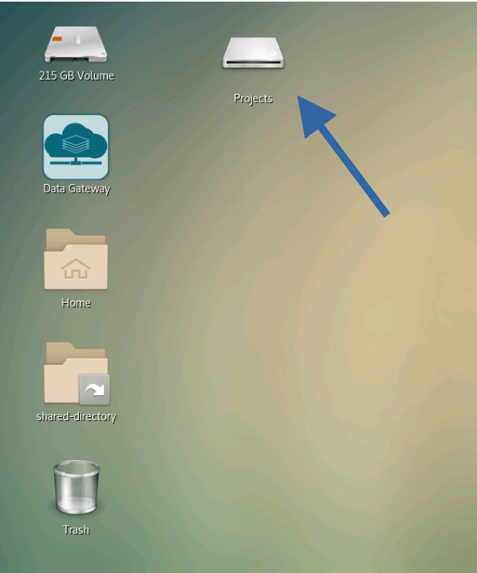

This is where all data and applications from SD Desktop reside. They are unencrypted on mount. Please note that the folder is read-only.

The Data Gateway can also be mounted over the command line with:

```
go-fuse -mount /media/volume/Projects
```

and closed with `Ctrl + C`.

## 2.3 The external backup drive

It is really important to save the data on the external drive. If the desktop crashes and needs rebooting everything in the shared or personal folders will be lost, but the external drive is not affected from this. The path to the external drive is `media/volume`.

I have set up the following structure on the external drive:

```
|-- admin
|  |-- documentation*
|  |  |-- images*
|  |-- scripts*
|  |-- encryption_keys
|-- bin
|-- users
|  |-- username
|-- data-out
|  |-- username

* these folder might only available within the FinRegistry admin project
```

## 2.4 The shared directory

Files saved to the `shared-directory` are visible to other project members. The data structure is the same as on the external drive. You can backup your file/folder from the `shared-directory` over the command line like:

```
cp <filename> /media/volume/users/<username>
cp -R /<folder> /media/volume/users/<username>
```

The `bin` directory in the shared directory is for executing singularity files, i.e. these are extra apas, that are not pre-installed in with SD Desktop.

**Note:** The “Shared” folder is specific to the virtual machine you are using. You won’t be able to see your files when logging into another machine unless to make them available on SD Connect.

## 2.5 Help pages inside SD Desktop

We have prepared a shared document inside SD Desktop.

- Connect to the Data Gateway
- Got to

```
Projects/SD\ connect/project_<projectnumber>/2004706_shared_admin_docs
```

where **projectnumber** is your CSC project number

- Open `working-with-sd-desktop.html` (actually any of the html files will also work, but you will need to scroll to the top of the document before saving) in Firefox
- Set as the homepage
  - Open Application Menu (top right)
  - Settings -> Home
  - Homepage and new windows
- You might also want to set new pages to be blank

The path will look like this:

[output not shown]

where **username** is your username and **projectnumber** is your project number.

[figure not shown]

## 2.6 Close your connection the SD Desktop

You can close your connection to your virtual Desktop in two ways:

Log out from your Desktop (in the workspace view, top right corner of the browser, select your username and log out). This will close all applications in your virtual Desktop and disconnect the work session. You will be able to access the virtual Desktop at any time after logging in to the services.

If you started a data analysis programmatically (you are running a script) you can close the browser window. This doesn’t interfere with the processes running. Thus, when you reconnect to your Desktop, you have all your tools and interfaces still open and can continue working. However, remember to log out from the Desktop once the analysis is finished. If you leave more than ten connections open, you will be unable to re-access the services.

**Reminder:** Never use the lock or reboot buttons in SD Desktop as you will not be able to connect to the Desktop again after that…